# Final for Exploratory Data Analysis for Machine Learning

## Exploratory Data Analysis with Housing in Ames, IA

#### 2020.11.30

## I. Data Set Description

I am using the Ames, Iowa dataset from the class notes. This dataset contains 2930 observations and 82 variables related to house sales in Ames, Iowa. The variables are related to characteristics and measurements of the house, its location, and its purchase.

Refer to the [codebook](http://jse.amstat.org/v19n3/decock/DataDocumentation.txt) for a complete list of variables and labels.

### 1. Packages

```python
from matplotlib import cm
import matplotlib.pyplot as plt
from matplotlib.ticker import FuncFormatter as FF
from matplotlib.ticker import StrMethodFormatter as SMF
import numpy as np
import pandas as pd
import seaborn as sns
from sklearn.linear_model import LinearRegression as LR
from sklearn.feature_selection import f_regression as fr
import statsmodels.api as sm
```

### 2. Load Data

```python
df = pd.read_csv('data/Ames_Housing_Data.tsv', sep = '\t')

#Set display options.
pd.options.display.max_rows = 100
pd.options.display.max_columns = 100

df.head()
```

|  | Order | PID | MS SubClass | MS Zoning | Lot Frontage | Lot Area | Street | Alley | Lot Shape | Land Contour | Utilities | Lot Config | Land Slope | Neighborhood | Condition 1 | Condition 2 | Bldg Type | House Style | Overall Qual | Overall Cond | Year Built | Year Remod/Add | Roof Style | Roof Matl | Exterior 1st | Exterior 2nd | Mas Vnr Type | Mas Vnr Area | Exter Qual | … |
| --- | --- | --- | --- | --- | --- | --- | --- | --- | --- | --- | --- | --- | --- | --- | --- | --- | --- | --- | --- | --- | --- | --- | --- | --- | --- | --- | --- | --- | --- | --- |
| 0 | 1 | 526301100 | 20 | RL | 141.0 | 31770 | Pave | NaN | IR1 | Lvl | AllPub | Corner | Gtl | NAmes | Norm | Norm | 1Fam | 1Story | 6 | 5 | 1960 | 1960 | Hip | CompShg | BrkFace | Plywood | Stone | 112.0 | TA | … |
| 1 | 2 | 526350040 | 20 | RH | 80.0 | 11622 | Pave | NaN | Reg | Lvl | AllPub | Inside | Gtl | NAmes | Feedr | Norm | 1Fam | 1Story | 5 | 6 | 1961 | 1961 | Gable | CompShg | VinylSd | VinylSd | None | 0.0 | TA | … |
| 2 | 3 | 526351010 | 20 | RL | 81.0 | 14267 | Pave | NaN | IR1 | Lvl | AllPub | Corner | Gtl | NAmes | Norm | Norm | 1Fam | 1Story | 6 | 6 | 1958 | 1958 | Hip | CompShg | Wd Sdng | Wd Sdng | BrkFace | 108.0 | TA | … |
| 3 | 4 | 526353030 | 20 | RL | 93.0 | 11160 | Pave | NaN | Reg | Lvl | AllPub | Corner | Gtl | NAmes | Norm | Norm | 1Fam | 1Story | 7 | 5 | 1968 | 1968 | Hip | CompShg | BrkFace | BrkFace | None | 0.0 | Gd | … |
| 4 | 5 | 527105010 | 60 | RL | 74.0 | 13830 | Pave | NaN | IR1 | Lvl | AllPub | Inside | Gtl | Gilbert | Norm | Norm | 1Fam | 2Story | 5 | 5 | 1997 | 1998 | Gable | CompShg | VinylSd | VinylSd | None | 0.0 | TA | … |

## II. Data Exploration Plan

I am going to select a few variables that are noteworthy and compare relationships between them and to *Sale Price*. The variables are varied between numerical and categorical, so I plan to choose interesting variables that would be of common interest that also contain a minimal number of missing values.

### 1. Data types

```python
df.dtypes.value_counts()
```

```
object     43
int64      28
float64    11
dtype: int64
```

### 2. Missing values

A count of missing values by variable is shown below.

```python
df_na = df.isna().sum().to_frame().sort_values(by = 0, axis = 0)

df_na.rename(columns={0: 'NA Count'}, inplace=True)

df_na[df_na['NA Count'] == 0].index
```

```
Index(['Order', 'Sale Condition', 'Heating QC', 'Central Air', '1st Flr SF',
       '2nd Flr SF', 'Low Qual Fin SF', 'Gr Liv Area', 'Full Bath',
       'Half Bath', 'Bedroom AbvGr', 'Kitchen AbvGr', 'Kitchen Qual',
       'Foundation', 'TotRms AbvGrd', 'Fireplaces', 'Paved Drive',
       'Wood Deck SF', 'Open Porch SF', 'Enclosed Porch', '3Ssn Porch',
       'Screen Porch', 'Pool Area', 'Misc Val', 'Mo Sold', 'Yr Sold',
       'Sale Type', 'Functional', 'Exter Cond', 'Heating', 'Condition 1',
       'House Style', 'Bldg Type', 'Condition 2', 'Exter Qual', 'Neighborhood',
       'Land Slope', 'Lot Config', 'Utilities', 'Land Contour', 'Lot Shape',
       'Street', 'Lot Area', 'MS Zoning', 'MS SubClass', 'PID', 'Overall Qual',
       'Overall Cond', 'SalePrice', 'Year Built', 'Year Remod/Add',
       'Roof Style', 'Roof Matl', 'Exterior 1st', 'Exterior 2nd'],
      dtype='object')
```

## III. Data Cleaning

I am looking at *Sale Price*, *Lot Area*, *Number of Bedrooms*, *Neighborhood*, *Year Built*, and *Overall Quality*. There are no missing values for this subset.

## IV. Key Findings

### 1. Exploration 1

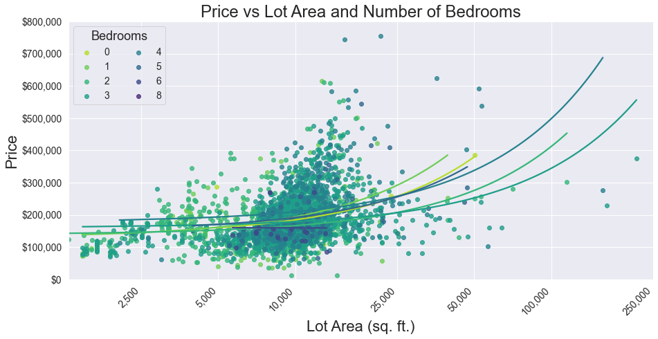

```python
sns.set()

#Scatter Plot.
exp1 = sns.lmplot(data = df, x = 'Lot Area', y = 'SalePrice', hue = 'Bedroom AbvGr',
                  palette = 'viridis_r', ci = None, height = 6, aspect = 13 / 6)

#Axes.
ax = plt.gca()

#Title setup.
ax.set_title('Price vs Lot Area and Number of Bedrooms', fontsize = 24)

#X-axis setup.
ax.set_xlabel("Lot Area (sq. ft.)", fontsize = 22)
ax.set_xscale('log')
xlabels = [2500, 5000, 10000, 25000, 50000, 100000, 250000]
ax.set_xticks(xlabels)
ax.set_xticklabels(xlabels, rotation = 45, ha = 'right')
ax.get_xaxis().set_major_formatter(FF(lambda x, p: format(int(x), ',')))

#Y-axis setup.
ax.set_ylabel("Price", fontsize = 22)
ax.set_ylim(0, 800000)
ax.yaxis.set_major_formatter(SMF('${x:,.0f}'))

ax.tick_params(axis = 'both', which = 'major', labelsize = 14)

#Legend setup.
exp1._legend.remove()
ax.legend(loc = 'upper left', title = 'Bedrooms', ncol = 2, title_fontsize = 18, fontsize = 14);
```

For the first exploration, *Price* is compared to *Lot Area* and Number of *Bedrooms*. *Lot Area* had a considerable right skew, so the x-axis was log scaled.

```python
bdrm_cnt = df['Bedroom AbvGr'].value_counts().sort_index().to_frame().rename(columns = {'Bedroom AbvGr': "Count of Houses"})
bdrm_cnt.index.name = "Number of Bedrooms"
bdrm_cnt
```

| Number of Bedrooms | Count of Houses |
| --- | --- |
| 0 | 8 |
| 1 | 112 |
| 2 | 743 |
| 3 | 1597 |
| 4 | 400 |
| 5 | 48 |
| 6 | 21 |
| 8 | 1 |

### 2. Exploration 2

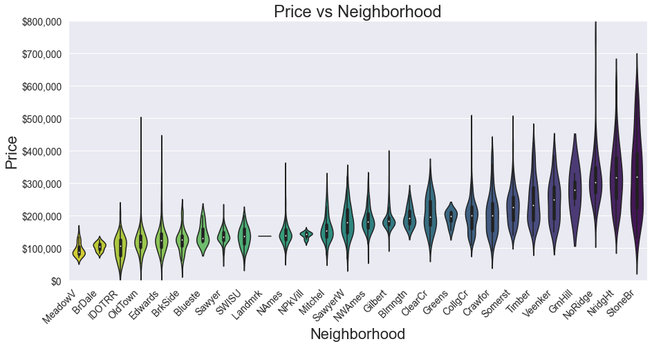

```python
#Sort Neighborhoods by median Price in ascending order.
xlabels = df.groupby(['Neighborhood'])['SalePrice'].median().sort_values().index

exp2 = sns.violinplot(data = df, x = 'Neighborhood', y = 'SalePrice', scale = 'width', width = 0.6,
                      palette = 'viridis_r', order = xlabels)

plt.gcf().set_size_inches(15, 6.92)

#Axes.
ax = plt.gca()

#Title setup.
ax.set_title('Price vs Neighborhood', fontsize = 24)

#X-axis setup.
ax.set_xlabel("Neighborhood", fontsize = 22)
ax.set_xticklabels(ax.get_xticklabels(), rotation = 45, ha = 'right')

#Y-axis setup.
ax.set_ylabel("Price", fontsize = 22)
ax.set_ylim(0, 800000)
ax.yaxis.set_major_formatter(SMF('${x:,.0f}'))

ax.tick_params(axis = 'both', which = 'major', labelsize = 14)
```

For the second exploration, *Price* is compared to *Neighborhood*. *Neighborhood* is represented by violin plots, sort in ascending order by median *Price*.

There is much overlap in *Price*, as there is significant and varying spread of house values within each *Neighborhood*. Overall there seems to be some correlation that warrants a further investigation.

### 3. Exploration 3

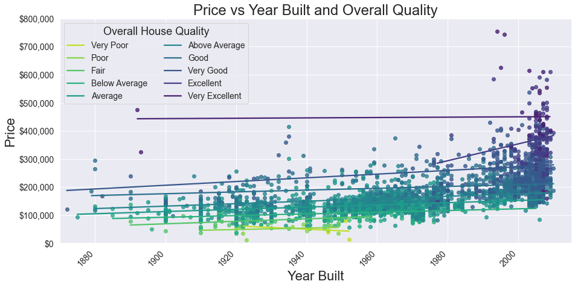

```python
#Scatter Plot.
exp3 = sns.lmplot(data = df, x = 'Year Built', y = 'SalePrice', hue = 'Overall Qual',
                  palette = 'viridis_r', ci = None, height = 6, aspect = 13 / 6)

#Axes.
ax = plt.gca()

#Title setup.
ax.set_title('Price vs Year Built and Overall Quality', fontsize = 24)

#X-axis setup.
ax.set_xlabel("Year Built", fontsize = 22)
ax.set_xlim(1870, 2015)
ax.set_xticklabels(ax.get_xticklabels(), rotation = 45, ha = 'right')

#Y-axis setup.
ax.set_ylabel("Price", fontsize = 22)
ax.set_ylim(0, 800000)
ax.yaxis.set_major_formatter(SMF('${x:,.0f}'))

ax.tick_params(axis = 'both', which = 'major', labelsize = 14)

#Legend setup.
exp3._legend.remove()
ax.legend(loc = 'upper left', title = 'Overall House Quality',
          labels = ['Very Poor', 'Poor', 'Fair', 'Below Average', 'Average',
                    'Above Average', 'Good', 'Very Good', 'Excellent', 'Very Excellent'],
          ncol = 2, title_fontsize = 18, fontsize = 14);
```

For the third exploration, *Price* is compared to *Year Built* and *Overall Quality*.

Comparing these three together is quite telling. Houses built earlier are of overall lower quality and lower selling price, as seen with the yellow, green, and cyan data points in the bottom of the graph. From 1990 - 2010, there is a sharp increase in quality and selling price, as seen with the blue, indigo, and purple data points on the far right of the graph.

The regression lines for *Overall Quality* show a positive relationship for *Year Built* and *Sale Price*. Furthurmore, there is very little intersection of these lines, they are clearly separated. The exception is 'Very Poor' and 'Poor' at the bottom center of the graph.

## V. Hypotheses

### 1. Hypothesis 1

An increase in *Lot Area* will increase *Sale Price*.

### 2. Hypothesis 2

Homes located in 'Green Hills', 'Northridge', 'Northridge Heights', and 'Stone Brook' have a greater *Sale Price* than homes located in other *Neighborhoods*

### 3. Hypothesis 3

An increase in *Overall Quality* will increase *Sale Price*.

## VI. Signifiance Test

H<sub>0</sub>: *Overall Quality* does not affect *Sale Price*.

H<sub>A</sub>: *Overall Quality* affects *Sale Price*.

```python
x = df['Overall Qual'].to_numpy().reshape(-1, 1)
y = df['SalePrice'].to_numpy().reshape(-1, )

reg = LR().fit(x, y)

r_sq = reg.score(x, y)
p_val = fr(x, y)[1][0]

print("The R-squared is {}.".format(round(r_sq, 3)))
print("The p_value is {}.".format(p_val))
```

```
The R-squared is 0.639.
The p_value is 0.0.
```

## VII. Future Analysis

Determining other variables with a high level of correlation, doing a multiple regression to explain more variance in *Sale Price*, and achieving significant results would be the next steps in this analysis.

## VIII. Data Summary

Although there are some missing values, the vast majority of this data is complete and of good quality.

Latitude and Longitude of houses, that is, there specific locations, may show to be a better indicator of price than *Neighborhood*.

It is important to stress that this model is specific to Ames, IA, and would vary greatly across the US. Although this data set of nearly 3,000 observations is satisfactory for a city, a much larger sample would be necessary for the US.